```python
%matplotlib inline
```

# 0. Import libraries

```python
import pandas as pd
import numpy as np
import matplotlib.pyplot as plt
from tqdm import tqdm_notebook as tqdm
```

```python
from sklearn.preprocessing import OneHotEncoder
from sklearn.metrics import log_loss, accuracy_score
```

```python
from keras.datasets import cifar100
from keras.models import Sequential
from keras.layers import Dense, Conv2D, MaxPooling2D, Flatten, Lambda, Input, BatchNormalization
from keras.optimizers import Adam, SGD, Optimizer
from keras.legacy import interfaces
from keras.preprocessing import image
from keras.callbacks import LearningRateScheduler
from keras.losses import categorical_crossentropy
from keras import backend as K
```

```python
import SGDR_keras
```

# 1.Download & preprocess CIFAR-100 data

Download CIFAR-100 data

```python
(X_train, y_train), (X_test, y_test) = cifar100.load_data()
(X_train.shape, y_train.shape, X_test.shape, y_test.shape)
```

```
((50000, 32, 32, 3), (50000, 1), (10000, 32, 32, 3), (10000, 1))
```

Check the shape of input data

```python
X_train.shape
```

```
(50000, 32, 32, 3)
```

Onehot encode target data

```python
enc = OneHotEncoder(sparse=False)
enc.fit(y_train.reshape(-1, 1))
```

```
OneHotEncoder(categorical_features='all', dtype=<class 'numpy.float64'>,
       handle_unknown='error', n_values='auto', sparse=False)
```

```python
y_train = enc.transform(y_train.reshape(-1, 1))
y_test = enc.transform(y_test.reshape(-1, 1))
```

```python
y_train[:1]
```

```
array([[0., 0., 0., 0., 0., 0., 0., 0., 0., 0., 0., 0., 0., 0., 0., 0.,
        0., 0., 0., 1., 0., 0., 0., 0., 0., 0., 0., 0., 0., 0., 0., 0.,
        0., 0., 0., 0., 0., 0., 0., 0., 0., 0., 0., 0., 0., 0., 0., 0.,
        0., 0., 0., 0., 0., 0., 0., 0., 0., 0., 0., 0., 0., 0., 0., 0.,
        0., 0., 0., 0., 0., 0., 0., 0., 0., 0., 0., 0., 0., 0., 0., 0.,
        0., 0., 0., 0., 0., 0., 0., 0., 0., 0., 0., 0., 0., 0., 0., 0.,
        0., 0., 0., 0.]])
```

Use `ImageDataGenerator` to make `batches` and `test_bathces`.  
Then make `batches` and `test_batches`

```python
batch_size = 2000
gen = image.ImageDataGenerator()
batches = gen.flow(X_train, y_train, batch_size=batch_size)
test_batches = image.ImageDataGenerator().flow(X_test, y_test, batch_size=batch_size)
```

Input data should be normalized before get into the model.  
Compute mean and standard deviation of trainin input data

```python
mean_px = np.array([X_train[:,:,:,0].mean(), X_train[:,:,:,1].mean(), X_train[:,:,:,2].mean()], dtype=np.float32)
std_px = np.array([X_train[:,:,:,0].std(), X_train[:,:,:,1].std(), X_train[:,:,:,2].std()], dtype=np.float32)
```

Define a function which return normalized input data.  
This function will be used as an input layer of model

```python
def norm_input(x): return (x-mean_px)/std_px
```

# 2. Define model

```python
def get_model():
    model = Sequential([
        Lambda(norm_input, input_shape=(32, 32, 3)),
        Conv2D(32,3, activation='relu', padding='same'),
        Conv2D(32,3, activation='relu', padding='same'),
        MaxPooling2D(),
        Conv2D(64,3, activation='relu', padding='same'),
        Conv2D(64,3, activation='relu', padding='same'),
        MaxPooling2D(),
        Conv2D(128,3, activation='relu', padding='same'),
        Conv2D(128,3, activation='relu', padding='same'),
        Conv2D(128,3, activation='relu', padding='same'),
        MaxPooling2D(),
        Conv2D(256,3, activation='relu', padding='same'),
        Conv2D(256,3, activation='relu', padding='same'),
        Conv2D(256,3, activation='relu', padding='same'),
        MaxPooling2D(),
        Flatten(),
        Dense(256, activation='relu'),
        BatchNormalization(),
        Dense(100, activation='softmax')
        ])
    return model
```

Get SGD and SGDR model

```python
model_sgd = get_model()
model_sgdr = get_model()
```

Set initial weight of SGD and SGDR model same to make identical initial starting point

```python
w = model_sgd.get_weights()
model_sgdr.set_weights(w)
```

# 3. Train model

```python
model_index = 1
```

```python
weight_path = 'weights/'
```

Since keras record training history only once per one epoch, number of epochs should be changed if moreh history information is needed.  
Real number of epochs and hypothetical number of epochs passed to keras is not matching.

```python
def get_epochs(n_epochs): return int(n_epochs * n_batch / steps_per_epoch)
```

```python
n_batch = len(batches); n_batch
```

```
25
```

After `n_batch` iterations, model trained for one real epoch.  
After `steps_per_epoch` iterations, model trained for one hypothetical epoch, therefore record training history information

### 3.1 Train SGD model

define a list which will record the training history information of SGD model

```python
sgd_hist = []
```

`steps_per_epoch` defines number of steps for one hypothetical epoch.  
Note that one real epoch is one cycle of full training data.  
If `steps_per_epoch` is small, than Keras will record training history information more ofthen.

```python
steps_per_epoch = 10
```

Compile the model with SGD optimizer and train the model

```python
sgd = SGD(lr=0.1)
model_sgd.compile(sgd, loss='categorical_crossentropy', metrics=['accuracy'])
```

```python
sgd_hist.append(model_sgd.fit_generator(batches, epochs=get_epochs(50),
                                        validation_data=test_batches, steps_per_epoch=steps_per_epoch, verbose=1))
model_sgd.evaluate_generator(batches)[1], model_sgd.evaluate_generator(test_batches)[1]
```

```
(0.9657799935340882, 0.39980000257492065)
```

```python
sgd_hist.append(model_sgd.fit_generator(batches, epochs=get_epochs(10),
                                        validation_data=test_batches, steps_per_epoch=steps_per_epoch, verbose=1))
model_sgd.evaluate_generator(batches)[1], model_sgd.evaluate_generator(test_batches)[1]
```

```
(0.99971999168396, 0.43040000200271605)
```

Training is over!  
Save the weights of the model.

```python
# model_sgd.save_weights(f'{weight_path}cifar100-sgd{model_index}.h5')
```

```python
# model_sgd.load_weights(f'{weight_path}cifar100-sgd{model_index}.h5')
```

### 3.2 Train SGDR model

```python
sgdr_hist = []
```

```python
steps_per_epoch = 10
lr = 0.2
```

`iter_per_epoch` of SGDR defines the number of iterations of one cycle of learning rate.  
If its same with `n_batch`, which is the number of iterations for one real epoch, then SGDR reset the learning rate for every epoch.

```python
sgdr = SGDR_keras.SGDR(lr=lr, iter_per_epoch=n_batch)
model_sgdr.compile(sgdr, loss='categorical_crossentropy', metrics=['accuracy'])
```

```python
sgdr_hist.append(model_sgdr.fit_generator(batches, epochs=get_epochs(1),
                                          validation_data=test_batches, steps_per_epoch=steps_per_epoch, verbose=1))
model_sgdr.evaluate_generator(batches)[1], model_sgdr.evaluate_generator(test_batches)[1]
```

```
(0.043960000276565554, 0.044600000232458116)
```

```python
sgdr = SGDR_keras.SGDR(lr=lr, iter_per_epoch=2*n_batch)
model_sgdr.compile(sgdr, loss='categorical_crossentropy', metrics=['accuracy'])
```

```python
sgdr_hist.append(model_sgdr.fit_generator(batches, epochs=get_epochs(2),
                                          validation_data=test_batches, steps_per_epoch=steps_per_epoch, verbose=1))
model_sgdr.evaluate_generator(batches)[1], model_sgdr.evaluate_generator(test_batches)[1]
```

```
(0.036999999955296514, 0.0340999998152256)
```

```python
sgdr = SGDR_keras.SGDR(lr=lr, iter_per_epoch=4*n_batch)
model_sgdr.compile(sgdr, loss='categorical_crossentropy', metrics=['accuracy'])
```

```python
sgdr_hist.append(model_sgdr.fit_generator(batches, epochs=get_epochs(4),
                                          validation_data=test_batches, steps_per_epoch=steps_per_epoch, verbose=1))
model_sgdr.evaluate_generator(batches)[1], model_sgdr.evaluate_generator(test_batches)[1]
```

```
(0.13390000015497208, 0.12870000004768373)
```

```python
sgdr = SGDR_keras.SGDR(lr=lr, iter_per_epoch=8*n_batch)
model_sgdr.compile(sgdr, loss='categorical_crossentropy', metrics=['accuracy'])
```

```python
sgdr_hist.append(model_sgdr.fit_generator(batches, epochs=get_epochs(8),
                                          validation_data=test_batches, steps_per_epoch=steps_per_epoch, verbose=1))
model_sgdr.evaluate_generator(batches)[1], model_sgdr.evaluate_generator(test_batches)[1]
```

```
(0.2516999989748001, 0.22939999997615815)
```

```python
sgdr = SGDR_keras.SGDR(lr=lr, iter_per_epoch=16*n_batch)
model_sgdr.compile(sgdr, loss='categorical_crossentropy', metrics=['accuracy'])
```

```python
sgdr_hist.append(model_sgdr.fit_generator(batches, epochs=get_epochs(15),
                                          validation_data=test_batches, steps_per_epoch=steps_per_epoch, verbose=1))
model_sgdr.evaluate_generator(batches)[1], model_sgdr.evaluate_generator(test_batches)[1]
```

```
(0.6334000039100647, 0.43269999623298644)
```

```python
sgdr = SGDR_keras.SGDR(lr=lr, iter_per_epoch=32*n_batch)
model_sgdr.compile(sgdr, loss='categorical_crossentropy', metrics=['accuracy'])
```

```python
sgdr_hist.append(model_sgdr.fit_generator(batches, epochs=get_epochs(31),
                                          validation_data=test_batches, steps_per_epoch=steps_per_epoch, verbose=1))
model_sgdr.evaluate_generator(batches)[1], model_sgdr.evaluate_generator(test_batches)[1]
```

```
(0.999159996509552, 0.4521999955177307)
```

Training is over!  
Save the weights of the model

```python
# model_sgdr.save_weights(f'{weight_path}cifar100-sgdr{model_index}.h5')
```

```python
# model_sgdr.load_weights(f'{weight_path}cifar100-sgdr{model_index}.h5')
```

# 4. Explore results

```python
def plot_hist(result, plot_type='loss', title='enter title!'):
    train_res, test_res = [], []

    for hist in result:
        train_res = train_res + hist.history[plot_type]
        test_res = test_res + hist.history[f'val_{plot_type}']

    plt.figure(figsize=(10,6))
    plt.title(title, size=15)
    plt.plot(train_res)
    plt.plot(test_res)
    plt.ylabel(plot_type)
    plt.xlabel('iterations')
    plt.legend(['train', 'test'], loc='upper right')
```

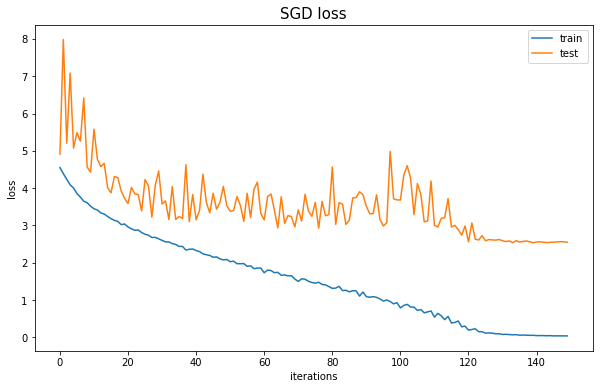

```python
plot_hist(sgd_hist, 'loss', 'SGD loss')
```

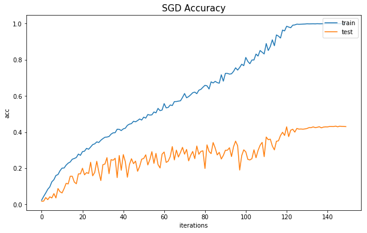

```python
plot_hist(sgd_hist, 'acc', 'SGD Accuracy')
```

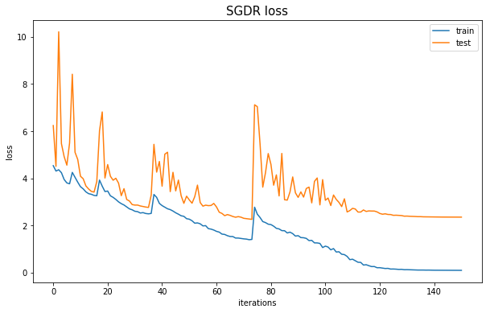

```python
plot_hist(sgdr_hist, 'loss', 'SGDR loss')
```

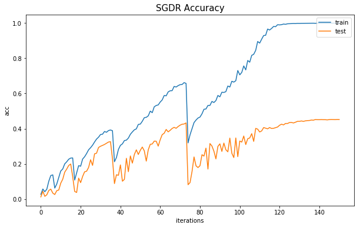

```python
plot_hist(sgdr_hist, 'acc', 'SGDR Accuracy')
```

# 5. filter normalization

`make_direction` function returns filter-normalized randomly generated direction corresponed to given model

```python
def make_direction(model):
    direction = []
    for l in model.layers:
        w = l.get_weights()

        #if layer is convolutional layer
        if isinstance(l, Conv2D):
            #make direction array
            filter_w = np.zeros(w[0].shape)
            bias_w = np.zeros(w[1].shape)

            for f in range(l.filters):
                for i in range(l.input_shape[3]):
                    #randomly generate direction
                    temp_direction = np.random.normal(size=w[0][:,:,i,f].shape)
                    temp_bias = np.random.normal(size=w[1][f].shape)

                    #compute norm of direction and original filter
                    norm_model = np.linalg.norm(w[0][:,:,i,f], ord='fro')
                    norm_direction = np.linalg.norm(temp_direction, ord='fro')

                    #normalize generated direction
                    temp_direction = temp_direction / norm_direction * norm_model
                    temp_bias = temp_bias / norm_direction * norm_model

                    #put generated one-filter direction to array
                    filter_w[:,:,i,f] = temp_direction
                    bias_w[f] = temp_bias

            #append generate one-layer direction to direction list
            direction.append(filter_w)
            direction.append(bias_w)

        #if layer is FC
        elif isinstance(l, Dense):

            #randomly generate direction
            temp_direction = np.random.normal(size=w[0].shape)
            temp_bias = np.random.normal(size=w[1].shape)

            #compute norm of direction and original layer
            norm_model = np.linalg.norm(w[0], ord='fro')
            norm_direction = np.linalg.norm(temp_direction, ord='fro')

            #normalize generated direction
            temp_direction = temp_direction / norm_direction * norm_model
            temp_bias = temp_bias / norm_direction * norm_model

            #put generated one-layer direction to array
            direction.append(temp_direction)
            direction.append(temp_bias)

        #if layer is BN
        elif isinstance(l, BatchNormalization):

            temp_direction_list = []

            #randomly generate direction
            for i in range(len(w)):
                temp_direction_list.append(np.zeros(w[i].shape))


            #put generated one-layer direction to array
            for d in temp_direction_list:
                direction.append(d)

    return direction
```

`direction_step` function returns model of which weight is alpha * direction + original_model_weights

```python
def direction_step(direction, model, alpha):

    step_model = get_model()
    step_model.compile(sgd, loss='categorical_crossentropy', metrics=['accuracy'])

    #get original model weights
    weight = model.get_weights()

    new_weights = []
    for i, w in enumerate(weight):
        new_weights.append(w + alpha * direction[i])

    step_model.set_weights(new_weights)

    return step_model
```

# 6. 1-D FN plot

```python
direction = make_direction(model_sgd)
```

```python
alpha_list = np.linspace(-1, 1, num=35)
```

```python
def step_1d_fn(model, alpha_list, direction):
    loss_train, acc_train = [], []
    loss_test, acc_test = [], []
#     direction = make_direction(model)

    for a in tqdm(alpha_list):
        temp_model = direction_step(direction, model, a)

        eval_train = temp_model.evaluate_generator(batches)
        eval_test = temp_model.evaluate_generator(test_batches)

        loss_train.append(eval_train[0])
        acc_train.append(eval_train[1])

        loss_test.append(eval_test[0])
        acc_test.append(eval_test[1])

    return loss_train, acc_train, loss_test, acc_test
```

```python
loss_sgd_train, acc_sgd_train, loss_sgd_test, acc_sgd_test = step_1d_fn(model_sgd, alpha_list, direction)
```

```python
loss_sgdr_train, acc_sgdr_train, loss_sgdr_test, acc_sgdr_test = step_1d_fn(model_sgdr, alpha_list, direction)
```

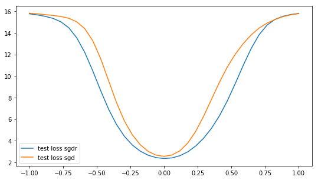

```python
plt.figure(figsize=(9,5))
plt.plot(alpha_list, loss_sgdr_test, label='test loss sgdr')
plt.plot(alpha_list, loss_sgd_test, label='test loss sgd')
plt.legend()
```

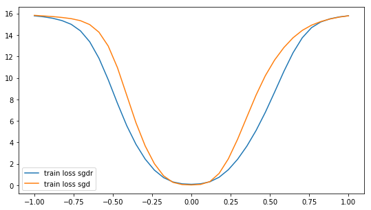

```python
plt.figure(figsize=(9,5))
plt.plot(alpha_list, loss_sgdr_train, label='train loss sgdr')
plt.plot(alpha_list, loss_sgd_train, label='train loss sgd')
plt.legend()
```

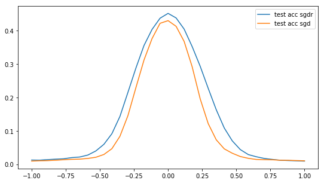

```python
plt.figure(figsize=(9,5))
plt.plot(alpha_list, acc_sgdr_test, label='test acc sgdr')
plt.plot(alpha_list, acc_sgd_test, label='test acc sgd')
plt.legend()
```

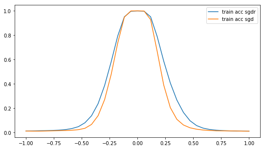

```python
plt.figure(figsize=(9,5))
plt.plot(alpha_list, acc_sgdr_train, label='train acc sgdr')
plt.plot(alpha_list, acc_sgd_train, label='train acc sgd')
plt.legend()
```

# 7. 2D FN plot

```python
path = 'data/'
```

```python
direction1 = make_direction(model_sgd)
direction2 = make_direction(model_sgd)
```

```python
alpha_list = np.linspace(-1, 1, num=13)
```

```python
def step_2d_fn(model, alpha_list, direction1, direction2):
    loss_test, acc_test = [], []

    for a1 in tqdm(alpha_list):
        tmp_loss, tmp_acc = [], []
        for a2 in (alpha_list):

            temp_model = direction_step(direction1, model, a1)
            temp_model = direction_step(direction2, temp_model, a2)

            eval_test = temp_model.evaluate_generator(test_batches)

            tmp_loss.append(eval_test[0])
            tmp_acc.append(eval_test[1])

        loss_test.append(tmp_loss)
        acc_test.append(tmp_acc)

    return loss_test, acc_test
```

```python
loss_sgd_test, acc_sgd_test = step_2d_fn(model_sgd, alpha_list, direction1, direction2)
```

```python
# np.save(f'{path}cifar100-loss_sgd_test.npy', np.array(loss_sgd_test))
```

```python
# loss_sgd_test=np.load(f'{path}cifar100-loss_sgd_test.npy')
```

```python
loss_sgdr_test, acc_sgdr_test = step_2d_fn(model_sgdr, alpha_list, direction1, direction2)
```

```python
# np.save(f'{path}cifar100-loss_sgdr_test.npy', np.array(loss_sgdr_test))
```

```python
# loss_sgdr_test=np.load(f'{path}cifar100-loss_sgdr_test.npy')
```

```
Text(0.5,1,'SGD test countour plot')
```

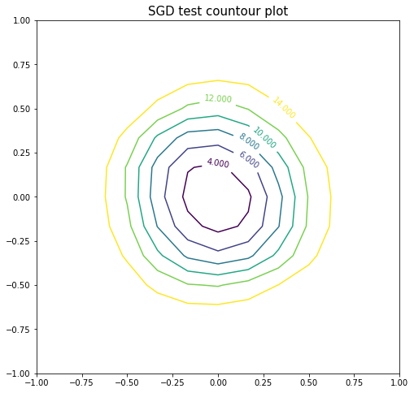

```python
plt.figure(figsize=(8,8))
# levels = np.arange(0,18,1.5)
c = plt.contour(alpha_list, alpha_list, loss_sgd_test)
plt.clabel(c, inline=1, fontsize=10)
plt.title('SGD test countour plot', fontsize=15)
```

```
Text(0.5,1,'SGDR test countour plot')
```

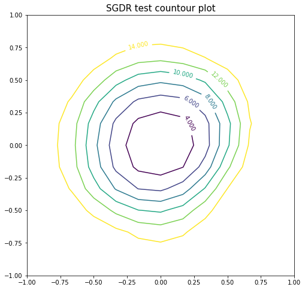

```python
plt.figure(figsize=(8,8))
c = plt.contour(alpha_list, alpha_list, loss_sgdr_test)
plt.clabel(c, inline=1, fontsize=10)
plt.title('SGDR test countour plot', fontsize=15)
```